# Regressão Linear

Nazareno Andrade (adaptado por Marcus Carvalho)

```r
library(openintro, quietly = TRUE)
library(tidyverse, quietly = TRUE)
library(modelr, quietly = TRUE)
library(broom, quietly = TRUE)
library(here, quietly = TRUE)
theme_set(theme_bw())
```

# Nosso objetivo

Até aqui, já conhecemos diferentes formas de sumarizar uma variável com uma estatística (ex: média, mediana, desvio padrão). Conhecemos também uma forma de avaliar a força e a direção da relação entre duas variáveis, com coeficientes de correlação.

Com regressão, queremos dar os seguintes passos adiante:

- descrever além da força e da direção de uma relação, sua *forma*. Por exemplo, queremos além de dizer que pessoas mais altas em geral pesam mais, dizer o quanto se espera que uma pessoa pese a mais se ela for 20cm mais alta que outra.
- descrever a relação entre mais de duas variáveis. Por exemplo, dizer que ao adicionar 1GB de memória a mais em uma VM (máquina virtual) e não mexer no número de vCPUs que ela tem, um servidor web rodando nessa VM conseguirá responder mais 20 req/s e adicionar uma vCPU sem mexer na memória aumenta a taxa de respostas em 40 req/s.

## Funções, modelos, famílias

Em regressão, descreveremos a relação entre variáveis como uma função matemática. Por exemplo, uma resposta de nossa análise será algo como uma dessas 3 funções:

- $reqs = 4 *mem + 10*vCPUs -2$, ou
- $reqs = 1.2 *mem^2 + 10*vCPUs -7.1$ ou
- $reqs = 2.1 *mem + 10*2^{vCPUs} - 4$

No primeiro exemplo, a taxa de requisição é uma função linear da quantidade de memória e do número de vCPUs. No segundo caso, a taxa de requisições aumenta com o quadrado do número de GBs de memória no nosso servidor. Isso quer dizer que o efeito de aumentar $mem$ de 0 para 1 ($=1.2*1 = 1.2$ nesse caso) não é o mesmo que o efeito de aumentar $mem$ de 1 para 2 ($=1.2*2^2 - 1.2=3.6$). Essa é a definição de não-linearidade, a propósito.

Na terceira função na lista, a taxa de requisições cresce exponencialmente com o número de vCPUs. Aumentar $vCPUs$ em uma unidade multiplica por 2 o valor do termo $10*2^{vCPUs}$.

Esses três exemplos dão exemplos de três famílias de funções: lineares, polinomiais e exponenciais. Em regressão construiremos funções para descrever a relação entre variáveis. Normalmente a escolha da família de funções a ser usada é uma escolha do analista. Os métodos de regressão servirão para encontrar os valores dos coeficientes na função que melhor se ajustam aos seus dados. Você depois utilizará estatística para afirmar quão bem a função que o método encontrou representa seus dados. E iterará nesse processo, claro.

# A intuição

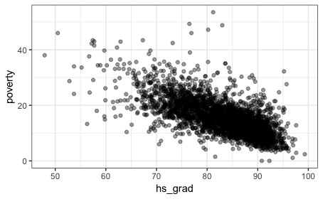

```r
data(countyComplete)
ggplot(countyComplete, aes(x = hs_grad, y = poverty)) +
  geom_point(alpha = 0.4)
```

```r
cor(countyComplete$poverty, countyComplete$hs_grad)
```

```
[1] -0.6807925
```

No olho:

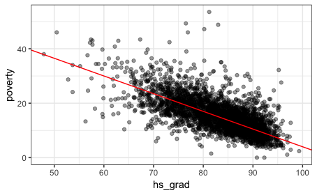

```r
ggplot(countyComplete, aes(x = hs_grad, y = poverty)) +
  geom_point(alpha = 0.4) +
  geom_abline(intercept = 69, slope = -.65, color  = "red")
```

lm == linear model

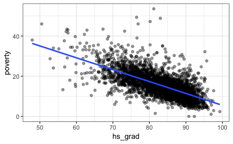

```r
ggplot(countyComplete, aes(x = hs_grad, y = poverty)) +
  geom_point(alpha = 0.4) + geom_smooth(method = "lm", se = FALSE)
```

```r
mod <- lm(poverty ~ hs_grad, data = countyComplete)
# sintaxe base R:
summary(mod)
```

```
Call:
lm(formula = poverty ~ hs_grad, data = countyComplete)

Residuals:
    Min      1Q  Median      3Q     Max
-18.035  -3.034  -0.434   2.405  36.874

Coefficients:
            Estimate Std. Error t value Pr(>|t|)
(Intercept) 64.59437    0.94619   68.27   <2e-16 ***
hs_grad     -0.59075    0.01134  -52.09   <2e-16 ***
---
Signif. codes:  0 ‘***’ 0.001 ‘**’ 0.01 ‘*’ 0.05 ‘.’ 0.1 ‘ ’ 1

Residual standard error: 4.677 on 3141 degrees of freedom
Multiple R-squared:  0.4635,    Adjusted R-squared:  0.4633
F-statistic:  2713 on 1 and 3141 DF,  p-value: < 2.2e-16
```

```r
confint(mod)
```

```
                 2.5 %   97.5 %
(Intercept) 62.7391581 66.44959
hs_grad     -0.6129825 -0.56851
```

```r
# broom, que acho mais recomendável:
tidy(mod, conf.int = TRUE)
```

| term | estimate | std.error | statistic | p.value | conf.low | conf.high |
| --- | --- | --- | --- | --- | --- | --- |
| (Intercept) | 64.5943749 | 0.94619183 | 68.26774 | 0 | 62.7391581 | 66.44959 |
| hs_grad | -0.5907462 | 0.01134085 | -52.09010 | 0 | -0.6129825 | -0.56851 |

```r
glance(mod) # depois falaremos desse
```

| r.squared | adj.r.squared | sigma | statistic | p.value | df | logLik | AIC | BIC | deviance | df.residual |
| --- | --- | --- | --- | --- | --- | --- | --- | --- | --- | --- |
| 0.4634785 | 0.4633077 | 4.676771 | 2713.378 | 0 | 2 | -9307.14 | 18620.28 | 18638.44 | 68700.54 | 3141 |

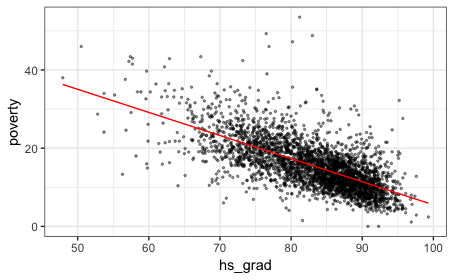

```r
countyComplete %>%
  add_predictions(model = mod) %>% # add o que o modelo estima p cada hs_grad
  ggplot(mapping = aes(x = hs_grad, y = poverty)) +
  geom_point(alpha = 0.4, size = .5) +
  geom_line(aes(y = pred), colour = "red")
```

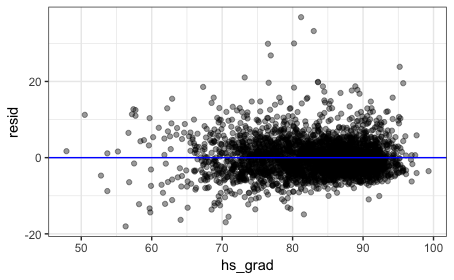

```r
countyComplete %>%
  add_residuals(model = mod) %>%
  ggplot(aes(hs_grad, resid)) +
  geom_point(alpha = .4) +
  geom_hline(yintercept = 0, colour = "blue")
```

## R^2 é a variância da variável de saída explicada pelo modelo

```r
# variância de y
var.y2 <- sum((countyComplete$poverty - mean(countyComplete$poverty))^2)
# variância dos resíduos do modelo
var.residuals <- sum(mod$residuals^2)
#calculando e conferindo o R^2
(var.y2 - var.residuals)/var.y2
```

```
[1] 0.4634785
```

```r
rsquare(mod, data = countyComplete)
```

```
[1] 0.4634785
```

```r
glance(mod)
```

| r.squared | adj.r.squared | sigma | statistic | p.value | df | logLik | AIC | BIC | deviance | df.residual |
| --- | --- | --- | --- | --- | --- | --- | --- | --- | --- | --- |
| 0.4634785 | 0.4633077 | 4.676771 | 2713.378 | 0 | 2 | -9307.14 | 18620.28 | 18638.44 | 68700.54 | 3141 |

Em outras situações, outras medidas de erro podem ser úteis

```r
rmse(mod, countyComplete)
```

```
[1] 4.675283
```

```r
mae(mod, countyComplete)
```

```
[1] 3.45496
```

```r
qae(mod, countyComplete)
```

```
       5%       25%       50%       75%       95%
0.2749207 1.3156567 2.7596222 4.6201044 9.2283417
```

## Bootstrap para inferência sobre os parâmetros do modelo

Trabalhando com uma amostra, geralmente queremos inferir o intervalo de confiança para os coeficientes do modelo que descreve a relação que estamos modelando *na população* de onde veio nossa amostra.

### Versão 1

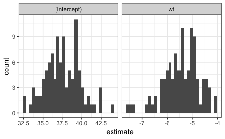

```r
library(purrr)
boot <- modelr::bootstrap(mtcars, 100)
models <- map(boot$strap, ~ lm(mpg ~ wt, data = .))
tidied <- map_df(models, broom::tidy, .id = "id")
tidied %>%
  ggplot(aes(x = estimate)) +
  geom_histogram(bins = 30) +
  facet_grid(. ~ term, scale = "free")
```

### Versão 2

```r
library(boot)
library(ISLR) # dados
attach(Auto)
```

Usando o pacote `boot` é preciso criar a função que será usada no bootstrap:

```r
boot.fn <- function(data, index) {
  return(coef(lm(mpg ~ horsepower, data=Auto, subset = index)))
}
boot.fn(Auto, 1:392)
```

```
(Intercept)  horsepower
 39.9358610  -0.1578447
```

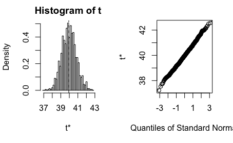

```r
regressao.b = boot(Auto, boot.fn, 1000)
# tidy(regressao.b, conf.int = TRUE, conf.method = "perc") tidy(boot.out) parece bugado em 2017-06-13
plot(regressao.b, index=1) # intercept
```

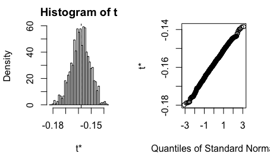

```r
plot(regressao.b, index=2) # horsepower
```

```r
boot.ci(regressao.b, type = "bca", index = 1)
```

```
BOOTSTRAP CONFIDENCE INTERVAL CALCULATIONS
Based on 1000 bootstrap replicates

CALL :
boot.ci(boot.out = regressao.b, type = "bca", index = 1)

Intervals :
Level       BCa
95%   (38.33, 41.64 )
Calculations and Intervals on Original Scale
```

```r
boot.ci(regressao.b, type = "bca", index = 2)
```

```
BOOTSTRAP CONFIDENCE INTERVAL CALCULATIONS
Based on 1000 bootstrap replicates

CALL :
boot.ci(boot.out = regressao.b, type = "bca", index = 2)

Intervals :
Level       BCa
95%   (-0.1711, -0.1439 )
Calculations and Intervals on Original Scale
```

### Opção com outro pacote

```r
library("simpleboot")
modelo.simples = lm(mpg ~ horsepower, data = Auto)
modelo.boot = lm.boot(modelo.simples, R = 1000)
summary(modelo.boot)
```

```
BOOTSTRAP OF LINEAR MODEL  (method = rows)

Original Model Fit
------------------
Call:
lm(formula = mpg ~ horsepower, data = Auto)

Coefficients:
(Intercept)   horsepower
    39.9359      -0.1578

Bootstrap SD's:
(Intercept)   horsepower
0.878377515  0.007500081
```

```r
perc(modelo.boot, c(.025, .975))
```

```
      (Intercept) horsepower
2.5%     38.40857 -0.1737994
97.5%    41.77447 -0.1445356
```

```r
# TODO : resampling de resíduos
#lboot2 <- lm.boot(modelo.simples, R = 1000, rows = FALSE)
#summary(lboot2)
```

# Diagnóstico dos modelos

http://stats.stackexchange.com/questions/58141/interpreting-plot-lm

```r
library(ggfortify)
tidy(mod)
```

| term | estimate | std.error | statistic | p.value |
| --- | --- | --- | --- | --- |
| (Intercept) | 64.5943749 | 0.94619183 | 68.26774 | 0 |
| hs_grad | -0.5907462 | 0.01134085 | -52.09010 | 0 |

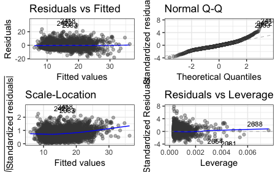

```r
autoplot(mod, label.size = 3, alpha = 0.4)
```

```r
# bem mais opções: http://rpubs.com/sinhrks/plot_lm
```

```r
library(GGally) # devtools::install_github("ggobi/ggally")
mario <- read_delim(here("dados", "marioKart.txt"), delim = "\t", col_types = "diicdddcicic") %>%
  mutate(stockPhoto = ifelse(stockPhoto == "yes", TRUE, FALSE))
glimpse(mario)
```

```
Observations: 143
Variables: 12
$ ID         <dbl> 150377422259, 260483376854, 320432342...
$ duration   <int> 3, 7, 3, 3, 1, 3, 1, 1, 3, 7, 1, 1, 1...
$ nBids      <int> 20, 13, 16, 18, 20, 19, 13, 15, 29, 8...
$ cond       <chr> "new", "used", "new", "new", "new", "...
$ startPr    <dbl> 0.99, 0.99, 0.99, 0.99, 0.01, 0.99, 0...
$ shipPr     <dbl> 4.00, 3.99, 3.50, 0.00, 0.00, 4.00, 0...
$ totalPr    <dbl> 51.55, 37.04, 45.50, 44.00, 71.00, 45...
$ shipSp     <chr> "standard", "firstClass", "firstClass...
$ sellerRate <int> 1580, 365, 998, 7, 820, 270144, 7284,...
$ stockPhoto <lgl> TRUE, TRUE, FALSE, TRUE, TRUE, TRUE, ...
$ wheels     <int> 1, 1, 1, 1, 2, 0, 0, 2, 1, 1, 2, 2, 2...
$ title      <chr> "~~ Wii MARIO KART &amp; WHEEL ~ NINT...
```

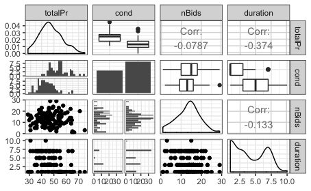

```r
mario = mario %>%
  filter(totalPr < 100)
mario %>%
  select(totalPr, cond, nBids, duration) %>%
  ggpairs(progress = FALSE)
```

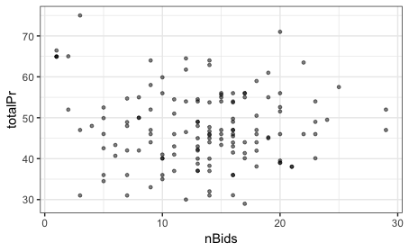

```r
mario %>%
  ggplot(aes(x = nBids, y = totalPr)) +
  geom_point(alpha = .5, size = 1)
```

```r
modelo = lm(totalPr ~ nBids, data = mario)
tidy(modelo, conf.int = TRUE) %>%
  select(-statistic, -std.error)
```

| term | estimate | p.value | conf.low | conf.high |
| --- | --- | --- | --- | --- |
| (Intercept) | 49.0979063 | 1.021836e-53 | 45.2482781 | 52.9475346 |
| nBids | -0.1244858 | 3.534019e-01 | -0.3888219 | 0.1398502 |

```r
glance(modelo)
```

| r.squared | adj.r.squared | sigma | statistic | p.value | df | logLik | AIC | BIC | deviance | df.residual |
| --- | --- | --- | --- | --- | --- | --- | --- | --- | --- | --- |
| 0.006198737 | -0.0009509121 | 9.117984 | 0.8669988 | 0.3534019 | 2 | -510.7082 | 1027.416 | 1036.263 | 11556.13 | 139 |

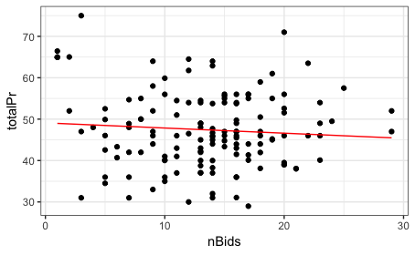

```r
mario %>%
  add_predictions(model = modelo) %>%
  ggplot(aes(x = nBids)) +
  geom_point(aes(y = totalPr)) +
  geom_line(aes(y = pred), color = "red")
```

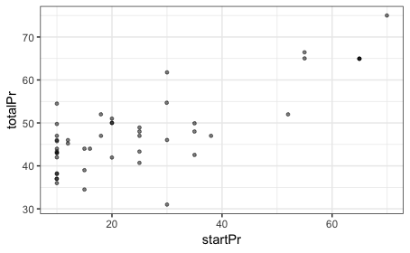

```r
mario %>%
  filter(startPr > 5) %>%
  ggplot(aes(x = startPr, y = totalPr)) +
  geom_point(alpha = .5, size = 1)
```

```r
mario2 = mario %>%
  filter(startPr > 5)
modelo = lm(totalPr ~ startPr, data = mario2)
tidy(modelo, conf.int = TRUE) %>%
  select(-statistic, -std.error)
```

| term | estimate | p.value | conf.low | conf.high |
| --- | --- | --- | --- | --- |
| (Intercept) | 37.7009781 | 6.642136e-28 | 34.6428649 | 40.7590913 |
| startPr | 0.4114764 | 1.726995e-10 | 0.3104925 | 0.5124604 |

```r
glance(modelo)
```

| r.squared | adj.r.squared | sigma | statistic | p.value | df | logLik | AIC | BIC | deviance | df.residual |
| --- | --- | --- | --- | --- | --- | --- | --- | --- | --- | --- |
| 0.5994723 | 0.5905717 | 5.974554 | 67.35179 | 1.726995e-10 | 2 | -149.6812 | 305.3623 | 310.9128 | 1606.288 | 45 |

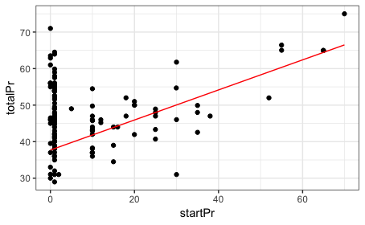

```r
mario %>%
  add_predictions(model = modelo) %>%
  ggplot(aes(x = startPr)) +
  geom_point(aes(y = totalPr)) +
  geom_line(aes(y = pred), color = "red")
```

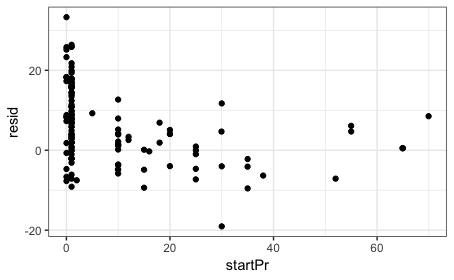

```r
mario %>%
  add_residuals(model = modelo) %>%
  ggplot(aes(x = startPr)) +
  geom_point(aes(y = resid))
```

# Preditor categórico

Usaremos preços de leilões de cartuchos de Mario Kart no eBay.

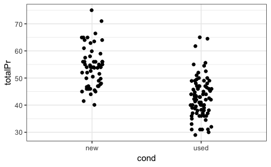

```r
mario %>%
  ggplot(aes(x = cond, y = totalPr)) +
  #geom_boxplot() +
  geom_jitter(width = .1)
```

```r
NA
```

```r
library(GGally) # devtools::install_github("ggobi/ggally")
mario <- read_delim(here("dados", "marioKart.txt"), delim = "\t", col_types = "diicdddcicic") %>%
  mutate(stockPhoto = ifelse(stockPhoto == "yes", TRUE, FALSE))
names(mario)
```

```
 [1] "ID"         "duration"   "nBids"      "cond"
 [5] "startPr"    "shipPr"     "totalPr"    "shipSp"
 [9] "sellerRate" "stockPhoto" "wheels"     "title"
```

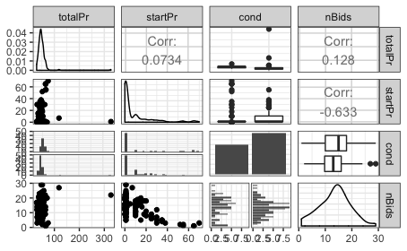

```r
mario %>%
  select(totalPr, startPr, cond, nBids) %>%
  ggpairs(progress = FALSE)
```

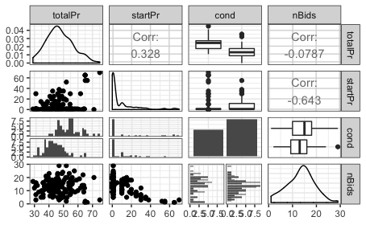

```r
mario <- filter(mario, totalPr < 100)
mario %>%
  select(totalPr, startPr, cond, nBids) %>%
  ggpairs(progress = FALSE)
```

A relação cond (novo/usado) x preço final do leilão.

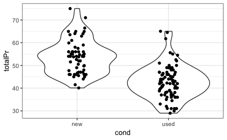

```r
mario %>%
  ggplot(aes(x = cond, y = totalPr)) +
  geom_violin() +
  geom_point(position = position_jitter(width = 0.1))
```

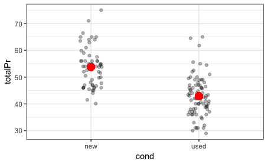

```r
mlm <- lm(totalPr ~ cond, data = mario)
mario %>%
  add_predictions(mlm) %>%
  ggplot(aes(x = cond)) +
  geom_jitter(aes(y = totalPr), width = .1, alpha = .3) +
  geom_point(aes(y = pred), color = "red", size = 4)
```

```r
tidy(mlm, conf.int = T) %>%
  select(-statistic, -std.error)
```

| term | estimate | p.value | conf.low | conf.high |
| --- | --- | --- | --- | --- |
| (Intercept) | 53.77068 | 2.730991e-97 | 51.87336 | 55.667998 |
| condused | -10.89958 | 1.055698e-14 | -13.38754 | -8.411621 |

```r
glance(mlm)
```

| r.squared | adj.r.squared | sigma | statistic | p.value | df | logLik | AIC | BIC | deviance | df.residual |
| --- | --- | --- | --- | --- | --- | --- | --- | --- | --- | --- |
| 0.3505528 | 0.3458805 | 7.370907 | 75.02818 | 1.055698e-14 | 2 | -480.7164 | 967.4329 | 976.2791 | 7551.908 | 139 |

```r
NA
```

## Introdução à regressão multivariada

Outras variáveis

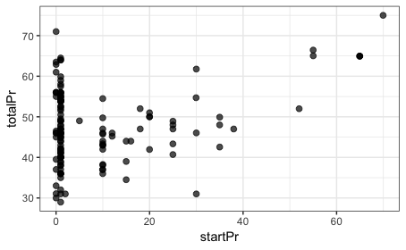

```r
mario %>%
  ggplot() +
  geom_point(aes(x = startPr, y = totalPr), size = 2, alpha = .7)
```

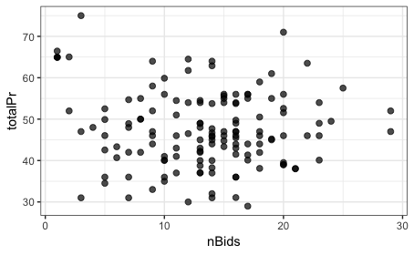

```r
mario %>%
  ggplot() +
  geom_point(aes(x = nBids, y = totalPr), size = 2, alpha = .7)
```

```r
mlm <- lm(totalPr ~ cond + startPr + cond * startPr, data = mario)
tidy(mlm, conf.int = T) %>%
  select(-statistic, -std.error)
```

| term | estimate | p.value | conf.low | conf.high |
| --- | --- | --- | --- | --- |
| (Intercept) | 52.26692383 | 2.843774e-92 | 50.28606767 | 54.2477800 |
| condused | -11.32225862 | 1.344842e-13 | -14.04441476 | -8.6001025 |
| startPr | 0.15464789 | 1.087523e-03 | 0.06302894 | 0.2462668 |
| condused:startPr | 0.07990267 | 3.351747e-01 | -0.08346650 | 0.2432718 |

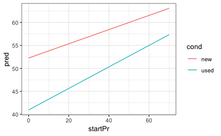

```r
model_plot = mario %>%
  data_grid(cond, startPr) %>%
  add_predictions(mlm)
model_plot %>%
  ggplot(aes(x  = startPr, y = pred, colour = cond)) +
  geom_line() #+
```

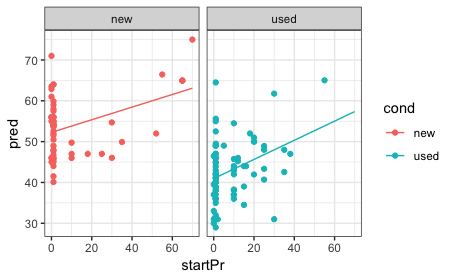

```r
  #facet_grid(. ~ cond)
model_plot %>%
  ggplot(aes(x  = startPr, y = pred, colour = cond)) +
  geom_line() +
  geom_point(data = mario, aes(y = totalPr)) +
  facet_grid(. ~ cond)
```

```r
tidy(mlm, conf.int = T)
```

| term | estimate | std.error | statistic | p.value | conf.low | conf.high |
| --- | --- | --- | --- | --- | --- | --- |
| (Intercept) | 52.26692383 | 1.00173202 | 52.1765531 | 2.843774e-92 | 50.28606767 | 54.2477800 |
| condused | -11.32225862 | 1.37661230 | -8.2247257 | 1.344842e-13 | -14.04441476 | -8.6001025 |
| startPr | 0.15464789 | 0.04633231 | 3.3377981 | 1.087523e-03 | 0.06302894 | 0.2462668 |
| condused:startPr | 0.07990267 | 0.08261686 | 0.9671472 | 3.351747e-01 | -0.08346650 | 0.2432718 |

```r
glance(mlm)
```

| r.squared | adj.r.squared | sigma | statistic | p.value | df | logLik | AIC | BIC | deviance | df.residual |
| --- | --- | --- | --- | --- | --- | --- | --- | --- | --- | --- |
| 0.4435591 | 0.4313743 | 6.872356 | 36.40255 | 2.297274e-17 | 4 | -469.8199 | 949.6398 | 964.3836 | 6470.411 | 137 |

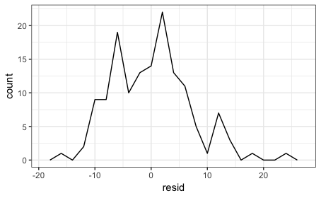

```r
mario = mario %>%
  add_residuals(mlm)
ggplot(mario, aes(resid)) +
  geom_freqpoly(binwidth = 2)
```

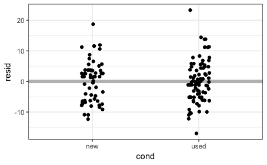

```r
ggplot(mario, aes(cond, resid)) +
  geom_ref_line(h = 0, colour = "grey") +
  geom_point(position = position_jitter(width = 0.1))
```

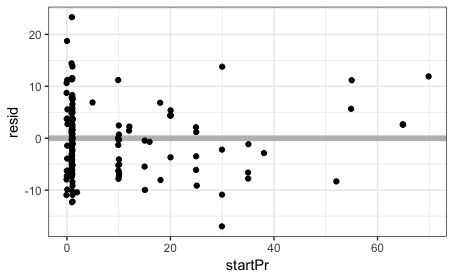

```r
ggplot(mario, aes(startPr, resid)) +
  geom_ref_line(h = 0, colour = "grey") +
  geom_point(position = position_jitter(width = 0.1))
```

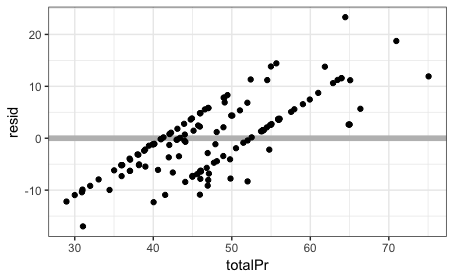

```r
ggplot(mario, aes(totalPr, resid)) +
  geom_ref_line(h = 0, colour = "grey") +
  geom_point(position = position_jitter(width = 0.1))
```

## Sobre múltiplas variáveis juntas num modelo

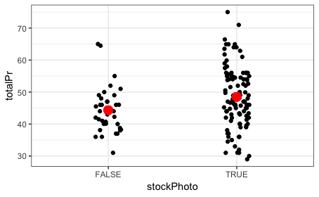

```r
mlm1 <- lm(totalPr ~ stockPhoto, data = mario)
mario %>%
  add_predictions(mlm1) %>%
  ggplot(aes(x = stockPhoto, y = totalPr)) +
  #geom_violin() +
  geom_point(position = position_jitter(width = 0.1))  +
  geom_point(aes(y = pred), size = 4, colour = "red")
```

```r
tidy(mlm1, conf.int = T) %>%
  select(-statistic, -std.error)
```

| term | estimate | p.value | conf.low | conf.high |
| --- | --- | --- | --- | --- |
| (Intercept) | 44.327222 | 5.092241e-62 | 41.3742287 | 47.280216 |
| stockPhotoTRUE | 4.169159 | 1.731116e-02 | 0.7471792 | 7.591138 |

```r
glance(mlm1)
```

| r.squared | adj.r.squared | sigma | statistic | p.value | df | logLik | AIC | BIC | deviance | df.residual |
| --- | --- | --- | --- | --- | --- | --- | --- | --- | --- | --- |
| 0.04007345 | 0.0331675 | 8.961238 | 5.802745 | 0.01731116 | 2 | -508.2633 | 1022.527 | 1031.373 | 11162.23 | 139 |

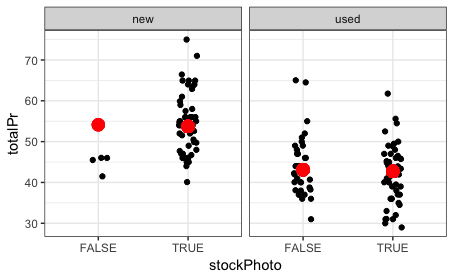

```r
mlm2 <- lm(totalPr ~ stockPhoto + cond, data = mario)
mario %>%
  add_predictions(mlm2) %>%
  ggplot(aes(x = stockPhoto, y = totalPr)) +
  #geom_violin() +
  geom_point(position = position_jitter(width = 0.1))  +
  geom_point(aes(y = pred), size = 4, colour = "red") +
  #geom_line(aes(y = pred, group = 1), size = 1, colour = "red") +
  facet_grid(. ~ cond)
```

```r
tidy(mlm2, conf.int = T) %>%
  select(-statistic, -std.error)
```

| term | estimate | p.value | conf.low | conf.high |
| --- | --- | --- | --- | --- |
| (Intercept) | 54.1245375 | 1.046536e-64 | 50.715545 | 57.533530 |
| stockPhotoTRUE | -0.3795948 | 8.049419e-01 | -3.413055 | 2.653866 |
| condused | -11.0219797 | 2.226737e-13 | -13.703316 | -8.340643 |

```r
glance(mlm2)
```

| r.squared | adj.r.squared | sigma | statistic | p.value | df | logLik | AIC | BIC | deviance | df.residual |
| --- | --- | --- | --- | --- | --- | --- | --- | --- | --- | --- |
| 0.3508408 | 0.3414327 | 7.395925 | 37.29134 | 1.127805e-13 | 3 | -480.6852 | 969.3703 | 981.1654 | 7548.56 | 138 |

```r
table(mario$stockPhoto, mario$cond)
```

```
        new used
  FALSE   4   32
  TRUE   55   50
```

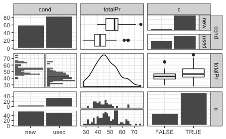

```r
mario %>%
  mutate(c  = as.character(stockPhoto)) %>%
  select(cond, totalPr, c) %>%
  ggpairs()
```

## Variáveis numéricas e categóricas juntas

```r
mlm <- lm(totalPr ~ startPr + cond, data = mario)
tidy(mlm)
```

| term | estimate | std.error | statistic | p.value |
| --- | --- | --- | --- | --- |
| (Intercept) | 52.0225670 | 0.96911880 | 53.680278 | 2.380375e-94 |
| startPr | 0.1797778 | 0.03835162 | 4.687621 | 6.559667e-06 |
| condused | -10.6280375 | 1.17438242 | -9.049895 | 1.198499e-15 |

```r
glance(mlm)
```

| r.squared | adj.r.squared | sigma | statistic | p.value | df | logLik | AIC | BIC | deviance | df.residual |
| --- | --- | --- | --- | --- | --- | --- | --- | --- | --- | --- |
| 0.43976 | 0.4316406 | 6.870747 | 54.16151 | 4.343232e-18 | 3 | -470.2996 | 948.5992 | 960.3943 | 6514.588 | 138 |

### Sobre causalidade

```r
mlm <- lm(totalPr ~ nBids + cond, data = mario)
tidy(mlm)
```

| term | estimate | std.error | statistic | p.value |
| --- | --- | --- | --- | --- |
| (Intercept) | 56.8857299 | 1.783796 | 31.890272 | 1.556679e-65 |
| nBids | -0.2214314 | 0.107385 | -2.062032 | 4.108076e-02 |
| condused | -11.1603276 | 1.250283 | -8.926239 | 2.436264e-15 |

```r
glance(mlm)
```

| r.squared | adj.r.squared | sigma | statistic | p.value | df | logLik | AIC | BIC | deviance | df.residual |
| --- | --- | --- | --- | --- | --- | --- | --- | --- | --- | --- |
| 0.3699651 | 0.3608341 | 7.286168 | 40.51774 | 1.432712e-14 | 3 | -478.577 | 965.154 | 976.9491 | 7326.178 | 138 |